# MVCO Grazing Analysis

Sophia Mirrashidi, Josephine Kaminaga, Holly Moeller

4/18/2023

## Importing data

The first step is to download the relevant tab of the Google Sheet as a .csv. Save it someplace that you can find it on your computer, so that you can import it into R as a data frame.

Here I’m loading the data file. I find it easiest to copy the complete file path from my computer. By storing the downloaded .csv file in the same folder, I can easily access the data even if I have downloaded a new copy. (I just need to make sure to “replace” the old file with the new one, instead of creating a new version.)

```r
extrdat <- read.csv("/Users/hollyvm/GoogleSync/Collaborations/MVCOCiliates/CiliateGrazingData - ExtractedData.csv",header=T)

str(extrdat) # The str() structure command is one of my favourites in R for quickly getting a sense for whether data import worked. I'm especially checking to make sure that R correctly imported my grazing rates and prey concentrations as numeric values.
```

```
## 'data.frame':    1739 obs. of  49 variables:
##  $ Date                                     : chr  "18 Oct 2022" "19 Oct 2022" "20 Oct 2022" "21 Oct 2022" ...
##  $ EnteredBy                                : chr  "HVM" "HVM" "HVM" "HVM" ...
##  $ Genus                                    : chr  "Mesodinium" "Mesodinium" "Mesodinium" "Mesodinium" ...
##  $ Species                                  : chr  "rubrum" "rubrum" "rubrum" "rubrum" ...
##  $ Strain                                   : chr  "Denmark" "Denmark" "Denmark" "Denmark" ...
##  $ Location                                 : chr  "Denmark" "Denmark" "Denmark" "Denmark" ...
##  $ Prey                                     : chr  "Teleaulax sp" "Teleaulax sp" "Teleaulax sp" "Teleaulax sp" ...
##  $ ExpType                                  : chr  "Lab" "Lab" "Lab" "Lab" ...
##  $ PubYear                                  : int  2006 2006 2006 2006 2006 2006 2006 2006 2006 2006 ...
##  $ Citation..please.link.to.PDF.in.database.: chr  "Hansen, P. J., & Fenchel, T. (2006). The bloom-forming ciliate Mesodinium rubrum harbours a single permanent en"| __truncated__ "Hansen, P. J., & Fenchel, T. (2006). The bloom-forming ciliate Mesodinium rubrum harbours a single permanent en"| __…
##  $ Data.Type                                : chr  "Ingestion" "Ingestion" "Ingestion" "Ingestion" ...
##  $ Media.Type                               : chr  "f/2" "f/2" "f/2" "f/2" ...
##  $ Light.Level                              : chr  "100" "100" "100" "100" ...
##  $ Temperature                              : num  15 15 15 15 15 15 15 15 15 15 ...
```

[output cut: 35 more lines]

To make it easier to sort through unique datasets, I’m going to add a column to our data frame that concatenates information about predator and prey.

```r
extrdat$Pred.Prey <- paste(extrdat$Genus,extrdat$Species,'.',extrdat$Prey,sep='')
# The paste() function concatenates strings. I'm using a "." to separate the predator and prey names. The "sep=''" argument tells R to concatenate the strings with no separation.

# We'll use the head() function and some subsetting commands to check our work.
names(extrdat) # Pulls the names of all the columns in extrdat
```

```
##  [1] "Date"
##  [2] "EnteredBy"
##  [3] "Genus"
##  [4] "Species"
##  [5] "Strain"
##  [6] "Location"
##  [7] "Prey"
##  [8] "ExpType"
##  [9] "PubYear"
## [10] "Citation..please.link.to.PDF.in.database."
## [11] "Data.Type"
## [12] "Media.Type"
## [13] "Light.Level"
## [14] "Temperature"
## [15] "Salinity"
```

[output cut: 35 more lines]

```r
names(extrdat)%in%c('Genus','Species','Prey','Pred.Prey') # Tells us which columns match the list of interest
```

```
##  [1] FALSE FALSE  TRUE  TRUE FALSE FALSE  TRUE FALSE FALSE FALSE FALSE FALSE
## [13] FALSE FALSE FALSE FALSE FALSE FALSE FALSE FALSE FALSE FALSE FALSE FALSE
## [25] FALSE FALSE FALSE FALSE FALSE FALSE FALSE FALSE FALSE FALSE FALSE FALSE
## [37] FALSE FALSE FALSE FALSE FALSE FALSE FALSE FALSE FALSE FALSE FALSE FALSE
## [49] FALSE  TRUE
```

```r
extrdat[1,1] # Pulls the first row and first column of extrdat
```

```
## [1] "18 Oct 2022"
```

```r
head(extrdat[,names(extrdat)%in%c('Genus','Species','Prey','Pred.Prey')]) # Displays the first six rows of the columns of interest in extrdat
```

```
##        Genus Species         Prey                     Pred.Prey
## 1 Mesodinium  rubrum Teleaulax sp Mesodiniumrubrum.Teleaulax sp
## 2 Mesodinium  rubrum Teleaulax sp Mesodiniumrubrum.Teleaulax sp
## 3 Mesodinium  rubrum Teleaulax sp Mesodiniumrubrum.Teleaulax sp
## 4 Mesodinium  rubrum Teleaulax sp Mesodiniumrubrum.Teleaulax sp
## 5 Mesodinium  rubrum Teleaulax sp Mesodiniumrubrum.Teleaulax sp
## 6 Mesodinium  rubrum Teleaulax sp Mesodiniumrubrum.Teleaulax sp
```

We can see that the concatenation worked!

## Loading packages

```r
# Nothing here for now but I'm sure we can think of something...
```

## Test case: Fitting a grazing curve

Let’s make a list of all the possible combinations we may have.

```r
head(unique(extrdat$Pred.Prey)) # Gives us a list of all of the unique predator-prey combinations; here I'm subsetting to just the first six so we're not overwhelmed
```

```
## [1] "Mesodiniumrubrum.Teleaulax sp"
## [2] "Mesodiniumrubrum.cryptophyte"
## [3] "Mesodiniumrubrum.Teleaulax amphioxeia"
## [4] "Mesodiniumrubrum.Teleaulax acuta"
## [5] "Balanionplanctonicum.Rhodomonas sp."
## [6] "Balanionsp.Heterocaspa triquetra"
```

```r
pred.prey.sets <- unique(extrdat$Pred.Prey) # Saves this list as a variable
length(pred.prey.sets) # Tells us how many there are
```

```
## [1] 154
```

The first example actually has some grazing data associated with it.

```r
pred.prey.sets[1] # Identify the first case study
```

```
## [1] "Mesodiniumrubrum.Teleaulax sp"
```

```r
extrdat[extrdat$Pred.Prey==pred.prey.sets[1],] # Subset the data by this predator/prey pair
```

```
##           Date EnteredBy      Genus Species  Strain Location         Prey
## 1  18 Oct 2022       HVM Mesodinium  rubrum Denmark  Denmark Teleaulax sp
## 2  19 Oct 2022       HVM Mesodinium  rubrum Denmark  Denmark Teleaulax sp
## 3  20 Oct 2022       HVM Mesodinium  rubrum Denmark  Denmark Teleaulax sp
## 4  21 Oct 2022       HVM Mesodinium  rubrum Denmark  Denmark Teleaulax sp
## 5  21 Oct 2022       HVM Mesodinium  rubrum Denmark  Denmark Teleaulax sp
## 6  21 Oct 2022       HVM Mesodinium  rubrum Denmark  Denmark Teleaulax sp
## 7  21 Oct 2022       HVM Mesodinium  rubrum Denmark  Denmark Teleaulax sp
## 8  21 Oct 2022       HVM Mesodinium  rubrum Denmark  Denmark Teleaulax sp
## 9  19 Oct 2022        SM Mesodinium  rubrum Denmark  Denmark Teleaulax sp
## 10 19 Oct 2022        SM Mesodinium  rubrum Denmark  Denmark Teleaulax sp
## 11 19 Oct 2022        SM Mesodinium  rubrum Denmark  Denmark Teleaulax sp
## 12 19 Oct 2022        JK Mesodinium  rubrum Denmark  Denmark Teleaulax sp
## 13 19 Oct 2022        SM Mesodinium  rubrum Denmark  Denmark Teleaulax sp
## 14 19 Oct 2022        SM Mesodinium  rubrum Denmark  Denmark Teleaulax sp
```

[output cut: 1129 more lines]

```r
subdat <- extrdat[extrdat$Pred.Prey==pred.prey.sets[1],] # Save this subset of data
dim(subdat) # Check the size of the matrix
```

```
## [1] 87 50
```

```r
subdat <- subdat[!is.na(subdat$PreyConsumption.preyperciliateperday),] # Extract just the rows that have grazing data (removing things that have NA)
dim(subdat)
```

```
## [1] 20 50
```

Let’s make a plot!

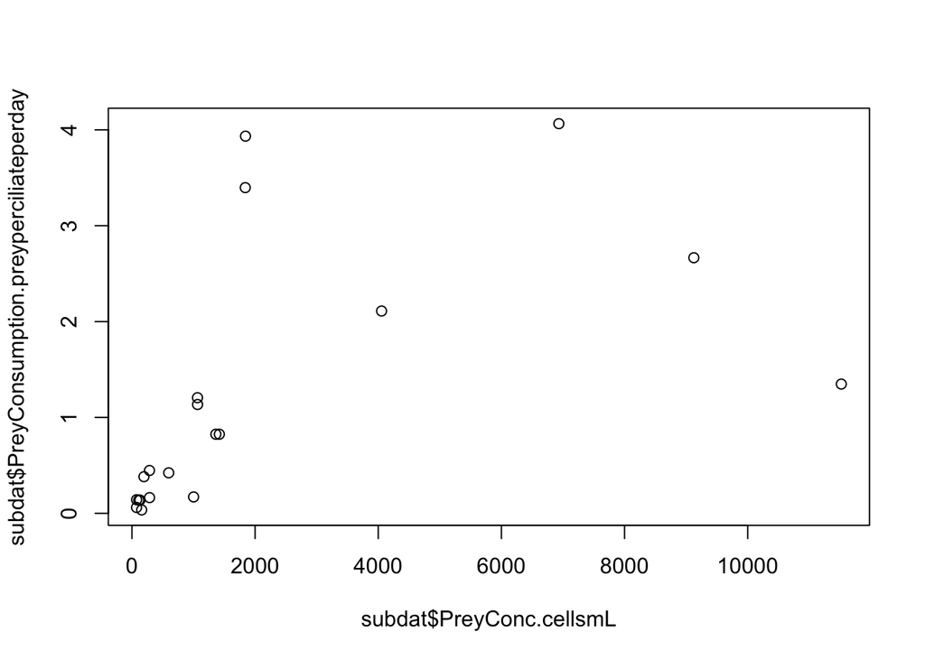

```r
plot(subdat$PreyConc.cellsmL,subdat$PreyConsumption.preyperciliateperday)
```

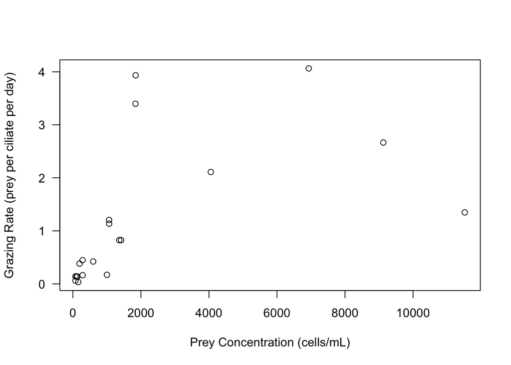

```r
# Adding some modifiers to make the plot more interpretable
plot(subdat$PreyConc.cellsmL,subdat$PreyConsumption.preyperciliateperday,las=1,xlab='Prey Concentration (cells/mL)',ylab='Grazing Rate (prey per ciliate per day)')
```

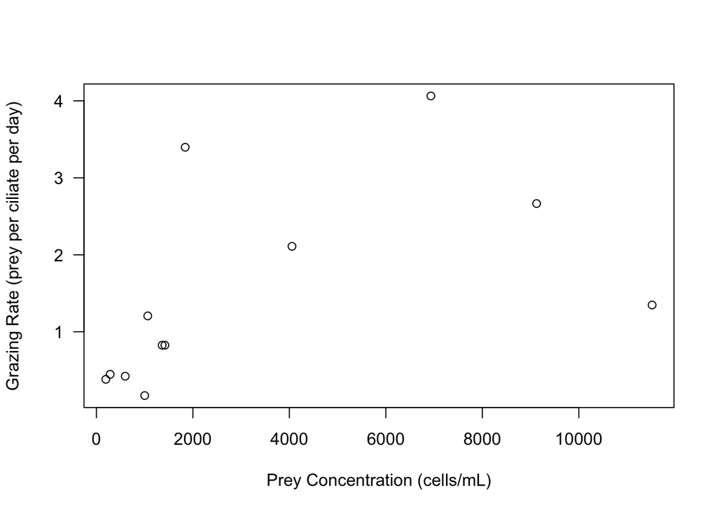

```r
# We can also check whether other experimental conditions really modify the grazing curve
subdat2 <- subdat[subdat$Salinity==35&subdat$Light.Level==100,]
plot(subdat2$PreyConc.cellsmL,subdat2$PreyConsumption.preyperciliateperday,las=1,xlab='Prey Concentration (cells/mL)',ylab='Grazing Rate (prey per ciliate per day)')
```

Now it’s time to try a curve fit. We’re going to use nls() for non-linear least squares regression. NLS is a pretty permissive function in that you can fit any curve shape you specify. But it’s picky about the start conditions that you give it.

```r
help(nls) # Pulls up the documentation for nls.
```

We are going to fit a Holling Type II Functional Response:

$$g = \frac{aP}{1+ahP}$$

```r
HollingFit <- nls(PreyConsumption.preyperciliateperday ~ a*PreyConc.cellsmL/(1+a*h*PreyConc.cellsmL),data=subdat,start=list(a=1/2000,h=1/4))

HollingFit
```

```
## Nonlinear regression model
##   model: PreyConsumption.preyperciliateperday ~ a * PreyConc.cellsmL/(1 +     a * h * PreyConc.cellsmL)
##    data: subdat
##        a        h
## 0.002132 0.305760
##  residual sum-of-squares: 14.45
##
## Number of iterations to convergence: 13
## Achieved convergence tolerance: 5.698e-06
```

```r
summary(HollingFit)
```

```
##
## Formula: PreyConsumption.preyperciliateperday ~ a * PreyConc.cellsmL/(1 +
##     a * h * PreyConc.cellsmL)
##
## Parameters:
##    Estimate Std. Error t value Pr(>|t|)
## a 0.0021319  0.0009963   2.140 0.046318 *
## h 0.3057598  0.0749167   4.081 0.000701 ***
## ---
## Signif. codes:  0 '***' 0.001 '**' 0.01 '*' 0.05 '.' 0.1 ' ' 1
##
## Residual standard error: 0.896 on 18 degrees of freedom
##
## Number of iterations to convergence: 13
## Achieved convergence tolerance: 5.698e-06
```

So we were able to fit this, but how did I come up with the guesses for a and h?

The attack rate is the initial slope. Let’s approximate this as the slope of the full dataset.

```r
lm(subdat$PreyConsumption.preyperciliateperday~subdat$PreyConc.cellsmL) # Linear model of the full dataset
```

```
##
## Call:
## lm(formula = subdat$PreyConsumption.preyperciliateperday ~ subdat$PreyConc.cellsmL)
##
## Coefficients:
##             (Intercept)  subdat$PreyConc.cellsmL
##               0.7032228                0.0002212
```

```r
lm(subdat$PreyConsumption.preyperciliateperday~subdat$PreyConc.cellsmL)$coefficients[2] # Slope from this linear model
```

```
## subdat$PreyConc.cellsmL
##            0.0002212312
```

```r
a.start <- lm(subdat$PreyConsumption.preyperciliateperday~subdat$PreyConc.cellsmL)$coefficients[2]
```

The handling time is the inverse of the max consumption rate.

```r
1/max(subdat$PreyConsumption.preyperciliateperday)
```

```
## [1] 0.246063
```

```r
h.start <- 1/max(subdat$PreyConsumption.preyperciliateperday)
```

Putting this all together…

```r
a.start <- lm(subdat$PreyConsumption.preyperciliateperday~subdat$PreyConc.cellsmL)$coefficients[2]
h.start <- 1/max(subdat$PreyConsumption.preyperciliateperday)

HollingFit <- nls(PreyConsumption.preyperciliateperday ~ a*PreyConc.cellsmL/(1+a*h*PreyConc.cellsmL),data=subdat,start=list(a=a.start,h=h.start))

HollingFit
```

```
## Nonlinear regression model
##   model: PreyConsumption.preyperciliateperday ~ a * PreyConc.cellsmL/(1 +     a * h * PreyConc.cellsmL)
##    data: subdat
##        a        h
## 0.002132 0.305759
##  residual sum-of-squares: 14.45
##
## Number of iterations to convergence: 14
## Achieved convergence tolerance: 7.886e-06
```

```r
summary(HollingFit)
```

```
##
## Formula: PreyConsumption.preyperciliateperday ~ a * PreyConc.cellsmL/(1 +
##     a * h * PreyConc.cellsmL)
##
## Parameters:
##    Estimate Std. Error t value Pr(>|t|)
## a 0.0021319  0.0009963   2.140 0.046318 *
## h 0.3057594  0.0749166   4.081 0.000701 ***
## ---
## Signif. codes:  0 '***' 0.001 '**' 0.01 '*' 0.05 '.' 0.1 ' ' 1
##
## Residual standard error: 0.896 on 18 degrees of freedom
##
## Number of iterations to convergence: 14
## Achieved convergence tolerance: 7.886e-06
```

```r
a.fit <- summary(HollingFit)$parameters[1,1]
h.fit <- summary(HollingFit)$parameters[2,1]
a.fit
```

```
## [1] 0.002131922
```

```r
h.fit
```

```
## [1] 0.3057594
```

Why do you think the fit attack rate is higher than the slope of all the data?

Finally, we can overlay this curve on our data and see how we did.

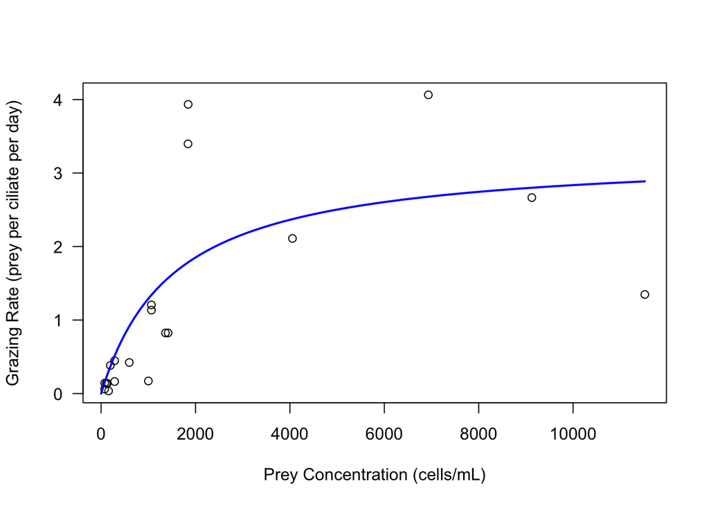

```r
plot(subdat$PreyConc.cellsmL,subdat$PreyConsumption.preyperciliateperday,las=1,xlab='Prey Concentration (cells/mL)',ylab='Grazing Rate (prey per ciliate per day)')

preyset <- seq(from = 0, to = max(subdat$PreyConc.cellsmL), length.out = 100) # Generate a list of x values
predicts <- a.fit*preyset/(1+a.fit*h.fit*preyset) # Use the Holling Functional Response to generate the predicted grazing rates for each prey value

lines(preyset,predicts,lwd=2,col='blue') # Add our curve to the plot using the 'lines' function
```